# ModelComparisonOptions

Ellie Weise

2026-01-20

## Elastic Net (current option)

```r
#load libraries
library(tidyverse)
library(glmnet)
library(MASS)
library(wesanderson)
library(ggforce)
###run clock with best CpG sites
CpGlist_best_4to15 <- read.csv(file = "Output/CpGList_LengthAge_Age4to15_121025.csv")
CpGlist_best_4to15$Set <- "Age4to15"
CpGlist_best_4to29 <- read.csv(file = "Output/CpGList_LengthAge_Age4to29_121025.csv")
CpGlist_best_4to29$Set <- "Age4to29"
CpGlist_all <- rbind(CpGlist_best_4to15,CpGlist_best_4to29)
##load data
# if doing clock from scratch
load("MethylKitInput/allCpGs_MinimalMissing.rda")
sexdata <- read.csv("Input/MethylWild_Sex_AgeData.csv")
```

### Preparing data for elastic net

```r
## Data prep ####
set.seed(2345678)
# subset to age 4-19 wild data
# get rid of sparse data issue for now as well
sexdata <- sexdata %>%
  filter(DataType == "Wild")

#running a glmnet with all selected sites
#CpGlist_all <- CpGlist_all %>% filter(ModelType == "Age")
bestCpGs <- allCpGs1[,which(colnames(allCpGs1) %in% CpGlist_all$CpGlist_best)]

#remove CpGs with NAs for the model
nas <- colSums(is.na(bestCpGs))
bestCpGs <- bestCpGs[,which(nas < 1)]
bestCpGs <- cbind(indivname=allCpGs1$indivname,bestCpGs)

#log age data
sexdata <- sexdata %>%
  mutate(LogAge = log(Age),LogLen = log(Length))
testdf <- full_join(sexdata,bestCpGs)
```

### Separating into Training and Testing Data Sets

```r
#randomly select individuals for testing
testpick <- sexdata %>%
  group_by(Age,ObsSex) %>%
  slice_sample(n = 1)

#sort other individuals into training data
trainpick <- sexdata[which(!(sexdata$indivname %in% testpick$indivname)),]

#select CpG sites for each group
testdat <- bestCpGs[which(bestCpGs$indivname %in% testpick$indivname),]
testdat <- left_join(testpick,testdat,by = "indivname")

traindat <- bestCpGs[which(!(bestCpGs$indivname %in% testpick$indivname)),]
traindat <- left_join(trainpick,traindat,by = "indivname")
```

### Run Elastic Net Model on Training Set and Predict Test Set

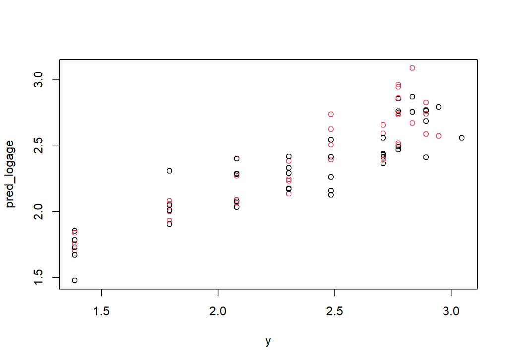

```r
## Full Data Model ####
#select data and run glmnet to select sites
y <- traindat$LogAge

#running a glmnet with all selected sites
bestCpG_train <- as.matrix(traindat[,which(colnames(traindat) %in% CpGlist_all$CpGlist_best)])

nas <- colSums(is.na(bestCpG_train))
bestCpG_train <- bestCpG_train[,which(nas < 1)]

model1 <- cv.glmnet(bestCpG_train,y,family = "gaussian",alpha = 0.05,nfolds = 20)
coef.allCpG <- as.matrix(coef(model1,s = "lambda.min"))

bestCpGnames <- names(coef.allCpG[which(coef.allCpG > 0),])

#predict testdat
ytest <- testdat$LogAge
xtest <- as.matrix(testdat[,which(colnames(testdat) %in% CpGlist_all$CpGlist_best)])
nas <- colSums(is.na(bestCpG_train))
xtest <- xtest[,which(nas < 1)]

#predict and correlate train data
pred_logage <- predict(model1,newx = bestCpG_train,type = "response",s = model1$lambda.1se)
colnames(pred_logage) <- "Epi_LogAge"
train_cor <- cor.test(y,pred_logage)
plot(y,pred_logage,col = traindat$ObsSex)
```

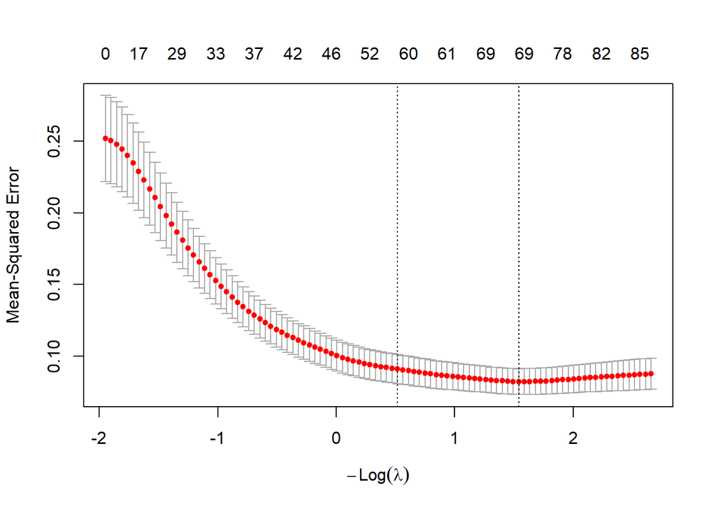

```r
plot(model1, xvar = "dev", label = TRUE)
```

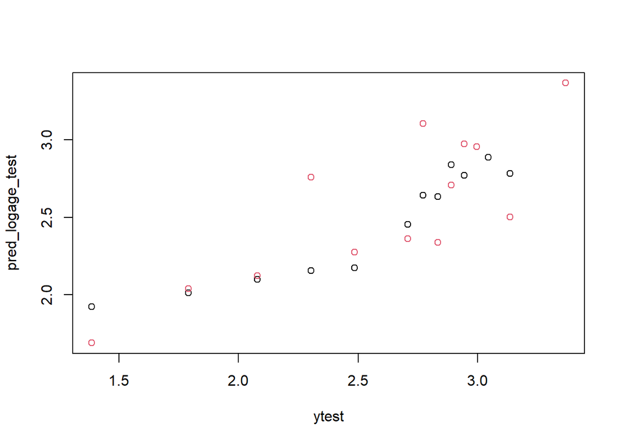

```r
#predict and correlate test data
pred_logage_test <- predict(model1,newx = xtest,type = "response",s = model1$lambda.1se)
colnames(pred_logage_test) <- "Epi_LogAge"
test_cor <- cor.test(ytest,pred_logage_test)
plot(ytest,pred_logage_test,col = testdat$ObsSex)
```

```r
#uncertainty for train and test
train_MAE <- median(abs(exp(y) - exp(pred_logage[ ,1])))
test_MAE <- median(abs(exp(ytest) - exp(pred_logage_test[ ,1])))
print(c(train_MAE,test_MAE))
```

```
## [1] 1.768221 2.848322
```

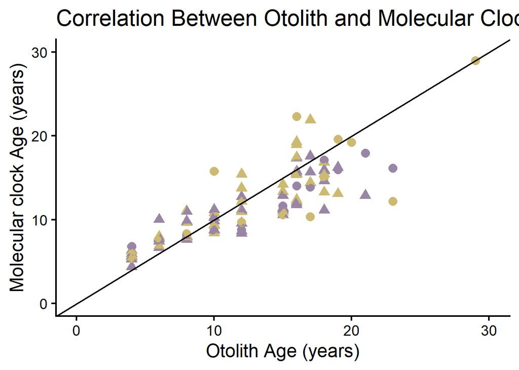

```r
# plot prediction
#clock correlation plot
train_res <- data.frame(indivname=traindat$indivname,
                        ObsSex=traindat$ObsSex,
                        Length=traindat$Length,
                        LogAge=y,
                        Epi_LogAge=pred_logage,
                        type="Train",
                        sampletype=traindat$DataType)
test_res <- data.frame(indivname=testdat$indivname,
                       ObsSex=testdat$ObsSex,
                       Length=testdat$Length,
                       LogAge=ytest,
                       Epi_LogAge=pred_logage_test,
                       type="Test",
                       sampletype=testdat$DataType)
res_comb_all <- rbind(train_res,test_res)
res_comb_all <- res_comb_all %>% mutate(Age=exp(LogAge),EpiAge=exp(Epi_LogAge)) %>%
  dplyr::select(-LogAge,-Epi_LogAge,-sampletype)
res_comb_all$SampleSet <- "Combined"
res_comb_all$ModelType <- "Elastic Net"

ggplot(res_comb_all,aes(x = Age,y = EpiAge,color=as.character(ObsSex),shape = type))+
  geom_point(size = 3.5)+
  geom_jitter(height = 0,width = 0.1)+
  ylim(0, 30) + xlim(0, 30) +
  geom_abline(slope = 1,intercept = 0) +
  xlab("Otolith Age (years)") +
  ylab("Molecular clock Age (years)") +
  ggtitle("Correlation Between Otolith and Molecular Clock Age") +
  scale_color_manual(values = c(wes_palette("IsleofDogs1")[1],wes_palette("IsleofDogs1")[3]))+
  theme_classic(base_size = 18) +
  theme(legend.position = "none")
```

I’ve also tried this option with male and female separated model options, but since we’re comparing overall methods I’m going to try these other options with the full data set first and then try it with male and female separated clocks once I have a better handle on the models. I also removed the hatchery data for now, it should help with the lack of 20+ age data, but they are all female and the age 23s look a little different from the wild data points around the same age, and I don’t know if that’s due to environmental difference or otolith error. Either way seems like a ‘next problem’ sort of thing.

# Attempts at Additive Models

So the big struggle I’m having here is with how to find which factors are best suited to be included in the additive model. I did graph percent methylation versus both otolith age and length, but even if I do one per CpG ‘region’ that we identified it’s still about 13 factors. I did still try that though and did a little bit of messing around with the edf values and linearity tests just to practice, along with a few randomly selected single CpG ones.

These factors were grabbed based on the graphs, which I feel kind of sketchy about, but I just wanted to get an idea of what these could look like after adding more factors.

```r
# check for multi-colinearity
library(mRMRe)
library(mgcv)
library(stats)

CpGs <- testdf %>% dplyr::select(starts_with("NC"))
Ages <- testdf$Age
indivnames <- testdf$indivname
sp_cors <- cor(CpGs,method = "spearman")

probs <- which(sp_cors > 0.7, arr.ind = TRUE)

probs1 <- data.frame(cpg1 = integer(0), cpg2 = integer(0), corval = integer(0))

for (i in 1:nrow(probs)) {
  if(probs[i,1] !=probs[i,2]){
    val <- sp_cors[probs[i,1],probs[i,2]]
    cpg1 <- rownames(sp_cors)[probs[i,1]]
    cpg2 <- colnames(sp_cors)[probs[i,2]]

    newrow <- c(cpg1,cpg2,val)

    probs1 <- rbind(probs1,newrow)
  }
}

## remove features that are repeating problems to start
colnames(probs1) <- c("cpg1","cpg2","corval")

CpGs_red <- CpGs[,which(!(colnames(CpGs) %in% names(table(probs1$cpg2) >= 2)))]

## try cor again and see how many are left
sp_cors1 <- cor(CpGs_red,method = "spearman")
probs_red <- which(sp_cors1 > 0.7, arr.ind = TRUE)

table(probs_red[,1] != probs_red[,2])
```

```
##
## FALSE
##    59
```

````r
## all false, meaning the colinear CpGs are gone

## run a huge gam model to check for concurvity
#!# takes a while, comment out before knitting
meta <- testdf %>% dplyr::select(indivname:DataType)
CpGs_red <- cbind(meta,CpGs_red)

# gam_concurv <- gam(Age ~ s(NC_047151.1.10551, bs="ts") +
# s(NC_047151.1.45, bs="ts") +
# s(NC_047151.1.7401, bs="ts") +
# s(NC_047151.1.9880, bs="ts") +
# s(NC_047152.1.11751, bs="ts") +
# s(NC_047152.1.1306, bs="ts") +
# s(NC_047153.1.32664060, bs="ts") +
# s(NC_047153.1.32666836, bs="ts") +
# s(NC_047153.1.32668125, bs="ts") +
# s(NC_047155.1.24555900, bs="ts") +
# s(NC_047155.1.30740795, bs="ts") +
# s(NC_047155.1.30748169, bs="ts") +
# s(NC_047157.1.604941, bs="ts") +
# s(NC_047159.1.29159906, bs="ts") +
# s(NC_047159.1.29160008, bs="ts") +
# s(NC_047161.1.22201614, bs="ts") +
# s(NC_047163.1.18713047, bs="ts") +
# s(NC_047163.1.21495116, bs="ts") +
# s(NC_047163.1.29031803, bs="ts") +
# s(NC_047163.1.29066999, bs="ts") +
# s(NC_047163.1.29069978, bs="ts") +
# s(NC_047163.1.29070020, bs="ts") +
# s(NC_047164.1.2171775, bs="ts") +
# s(NC_047164.1.2171813, bs="ts") +
# s(NC_047164.1.24801420, bs="ts") +
# s(NC_047165.1.15408994, bs="ts") +
# s(NC_047165.1.15411905, bs="ts") +
# s(NC_047165.1.15412428, bs="ts") +
# s(NC_047165.1.906817, bs="ts") +
# s(NC_047165.1.906821, bs="ts") +
# s(NC_047165.1.907148, bs="ts") +
# s(NC_047165.1.908834, bs="ts") +
# s(NC_047165.1.912498, bs="ts") +
# s(NC_047167.1.11015458, bs="ts") +
# s(NC_047168.1.480431, bs="ts") +
# s(NC_047170.1.1470, bs="ts") +
# s(NC_047170.1.1540, bs="ts") +
# s(NC_047171.1.15408463, bs="ts") +
# s(NC_047171.1.2287136, bs="ts") +
# s(NC_047171.1.25040373, bs="ts") +
# s(NC_047172.1.24804623, bs="ts") +
# s(NC_047172.1.24835778, bs="ts") +
# s(NC_047172.1.26288943, bs="ts") +
# s(NC_047172.1.26289238, bs="ts") +
# s(NC_047172.1.26290161, bs="ts") +
# s(NC_047172.1.26290162, bs="ts") +
# s(NC_047172.1.26294605, bs="ts") +
# s(NC_047172.1.26305026, bs="ts") +
# s(NC_047172.1.26305253, bs="ts") +
# s(NC_047174.1.21422892, bs="ts") +
# s(NC_047174.1.21423903, bs="ts") +
# s(NC_047174.1.21425138, bs="ts") +
# s(NC_047174.1.21427009, bs="ts") +
# s(NC_047174.1.21428354, bs="ts") +
# s(NC_047174.1.21431627, bs="ts") +
# s(NC_047174.1.21434992, bs="ts") +
# s(NC_047174.1.21435010, bs="ts") +
# s(NC_047174.1.21435011, bs="ts") +
# s(NC_047174.1.21435056, bs="ts"),
# select = T,data = CpGs_red,method = "REML")
# ```
#
# ```{r}
# concur <- concurvity(b=gam_concurv,full = F)
#
# range(concur[["estimate"]])
# hist(concur[["estimate"]])
#
# which(concur[["estimate"]] > 0.9, arr.ind = TRUE)
#
# summary(gam_concurv)

# use concurvity model (since no vars were eliminated)
# to linearize vars and eliminate non-significant vars that were not selected
gam_reduce <- gam(Age ~ s(NC_047151.1.10551, bs="ts") +
#s(NC_047151.1.45, bs="ts") +
#s(NC_047151.1.7401, bs="ts") +
s(NC_047151.1.9880, bs="ts") +
#s(NC_047152.1.11751, bs="ts") +
#s(NC_047152.1.1306, bs="ts") +
s(NC_047153.1.32664060, bs="ts") +
s(NC_047153.1.32666836, bs="ts") +
s(NC_047153.1.32668125, bs="ts") +
#s(NC_047155.1.24555900, bs="ts") +
s(NC_047155.1.30740795, bs="ts") +
#s(NC_047155.1.30748169, bs="ts") +
#s(NC_047157.1.604941, bs="ts") +
s(NC_047159.1.29159906, bs="ts") +
#s(NC_047159.1.29160008, bs="ts") +
s(NC_047161.1.22201614, bs="ts") +
#s(NC_047163.1.18713047, bs="ts") +
s(NC_047163.1.21495116, bs="ts") +
#s(NC_047163.1.29031803, bs="ts") +
#s(NC_047163.1.29066999, bs="ts") +
#s(NC_047163.1.29069978, bs="ts") +
#s(NC_047163.1.29070020, bs="ts") +
#s(NC_047164.1.2171775, bs="ts") +
s(NC_047164.1.2171813, bs="ts") +
s(NC_047164.1.24801420, bs="ts") +
s(NC_047165.1.15408994, bs="ts") +
s(NC_047165.1.15411905, bs="ts") +
#s(NC_047165.1.15412428, bs="ts") +
#s(NC_047165.1.906817, bs="ts") +
s(NC_047165.1.906821, bs="ts") +
#s(NC_047165.1.907148, bs="ts") +
s(NC_047165.1.908834, bs="ts") +
s(NC_047165.1.912498, bs="ts") +
s(NC_047167.1.11015458, bs="ts") +
#s(NC_047168.1.480431, bs="ts") +
s(NC_047170.1.1470, bs="ts") +
#s(NC_047170.1.1540, bs="ts") +
s(NC_047171.1.15408463, bs="ts") +
s(NC_047171.1.2287136, bs="ts") +
s(NC_047171.1.25040373, bs="ts") +
#s(NC_047172.1.24804623, bs="ts") +
s(NC_047172.1.24835778, bs="ts") +
s(NC_047172.1.26288943, bs="ts") +
#s(NC_047172.1.26289238, bs="ts") +
#s(NC_047172.1.26290161, bs="ts") +
#s(NC_047172.1.26290162, bs="ts") +
#s(NC_047172.1.26294605, bs="ts") +
s(NC_047172.1.26305026, bs="ts") +
#s(NC_047172.1.26305253, bs="ts") +
#s(NC_047174.1.21422892, bs="ts") +
#s(NC_047174.1.21423903, bs="ts") +
s(NC_047174.1.21425138, bs="ts") +
s(NC_047174.1.21427009, bs="ts") +
s(NC_047174.1.21428354, bs="ts") +
s(NC_047174.1.21431627, bs="ts") +
s(NC_047174.1.21434992, bs="ts") +
#s(NC_047174.1.21435010, bs="ts") +
s(NC_047174.1.21435011, bs="ts") +
s(NC_047174.1.21435056, bs="ts"),
select = T,data = CpGs_red,method = "REML")

summary(gam_reduce)
````

```
##
## Family: gaussian
## Link function: identity
##
## Formula:
## Age ~ s(NC_047151.1.10551, bs = "ts") + s(NC_047151.1.9880, bs = "ts") +
##     s(NC_047153.1.32664060, bs = "ts") + s(NC_047153.1.32666836,
##     bs = "ts") + s(NC_047153.1.32668125, bs = "ts") + s(NC_047155.1.30740795,
##     bs = "ts") + s(NC_047159.1.29159906, bs = "ts") + s(NC_047161.1.22201614,
##     bs = "ts") + s(NC_047163.1.21495116, bs = "ts") + s(NC_047164.1.2171813,
##     bs = "ts") + s(NC_047164.1.24801420, bs = "ts") + s(NC_047165.1.15408994,
##     bs = "ts") + s(NC_047165.1.15411905, bs = "ts") + s(NC_047165.1.906821,
##     bs = "ts") + s(NC_047165.1.908834, bs = "ts") + s(NC_047165.1.912498,
##     bs = "ts") + s(NC_047167.1.11015458, bs = "ts") + s(NC_047170.1.1470,
##     bs = "ts") + s(NC_047171.1.15408463, bs = "ts") + s(NC_047171.1.2287136,
##     bs = "ts") + s(NC_047171.1.25040373, bs = "ts") + s(NC_047172.1.24835778,
##     bs = "ts") + s(NC_047172.1.26288943, bs = "ts") + s(NC_047172.1.26305026,
##     bs = "ts") + s(NC_047174.1.21425138, bs = "ts") + s(NC_047174.1.21427009,
##     bs = "ts") + s(NC_047174.1.21428354, bs = "ts") + s(NC_047174.1.21431627,
##     bs = "ts") + s(NC_047174.1.21434992, bs = "ts") + s(NC_047174.1.21435011,
##     bs = "ts") + s(NC_047174.1.21435056, bs = "ts")
##
## Parametric coefficients:
##             Estimate Std. Error t value Pr(>|t|)
## (Intercept)  12.4811     0.1686   74.05   <2e-16 ***
## ---
## Signif. codes:  0 '***' 0.001 '**' 0.01 '*' 0.05 '.' 0.1 ' ' 1
##
## Approximate significance of smooth terms:
##                            edf Ref.df      F  p-value
## s(NC_047151.1.10551)    3.5092      9 21.195 0.001084 **
## s(NC_047151.1.9880)     0.9197      9  2.581 0.004750 **
## s(NC_047153.1.32664060) 0.3717      9  0.067 0.180926
## s(NC_047153.1.32666836) 0.6339      9  0.210 0.079893 .
## s(NC_047153.1.32668125) 0.6305      9  0.191 0.088755 .
## s(NC_047155.1.30740795) 0.7218      9  0.292 0.055921 .
## s(NC_047159.1.29159906) 0.8386      9  0.542 0.015845 *
## s(NC_047161.1.22201614) 0.8124      9  0.461 0.021628 *
## s(NC_047163.1.21495116) 0.7869      9  0.394 0.030247 *
## s(NC_047164.1.2171813)  0.9154      9  0.970 0.002217 **
```

[output cut: 11 more lines]

```
## s(NC_047172.1.24835778) 2.1036      9  4.519 0.001897 **
## s(NC_047172.1.26288943) 0.2250      9  0.033 0.227058
## s(NC_047172.1.26305026) 2.5224      9 10.946 0.009217 **
## s(NC_047174.1.21425138) 1.0442      9  3.609 2.91e-05 ***
## s(NC_047174.1.21427009) 0.9238      9  0.936 0.002015 **
## s(NC_047174.1.21428354) 0.6814      9  0.243 0.065886 .
## s(NC_047174.1.21431627) 0.9306      9  2.607 0.001756 **
## s(NC_047174.1.21434992) 3.0718      9 90.260 0.000233 ***
## s(NC_047174.1.21435011) 1.2155      9 13.137  < 2e-16 ***
## s(NC_047174.1.21435056) 0.9551      9  1.216 0.000598 ***
## ---
## Signif. codes:  0 '***' 0.001 '**' 0.01 '*' 0.05 '.' 0.1 ' ' 1
##
## R-sq.(adj) =  0.897   Deviance explained = 93.2%
## -REML = 264.43  Scale est. = 3.0116    n = 106
```

```r
## take out non-sig factors
gam_reduce <- gam(Age ~ s(NC_047151.1.10551, bs="ts") +
NC_047151.1.9880 +
#s(NC_047153.1.32664060, bs="ts") +
NC_047153.1.32666836 +
NC_047153.1.32668125 +
NC_047155.1.30740795 +
NC_047159.1.29159906+
NC_047161.1.22201614 +
NC_047163.1.21495116 +
NC_047164.1.2171813 +
NC_047164.1.24801420 +
NC_047165.1.15408994 +
NC_047165.1.15411905 +
s(NC_047165.1.906821, bs="ts") +
NC_047165.1.908834 +
NC_047165.1.912498 +
s(NC_047167.1.11015458, bs="ts") +
#s(NC_047170.1.1470, bs="ts") +
NC_047171.1.15408463 +
NC_047171.1.2287136 +
NC_047171.1.25040373 +
s(NC_047172.1.24835778, bs="ts") +
#s(NC_047172.1.26288943, bs="ts") +
s(NC_047172.1.26305026, bs="ts") +
NC_047174.1.21425138 +
NC_047174.1.21427009 +
NC_047174.1.21428354 +
NC_047174.1.21431627 +
s(NC_047174.1.21434992, bs="ts") +
NC_047174.1.21435011 +
NC_047174.1.21435056,
select = T,data = CpGs_red,method = "REML")

CpGs_red$ObsSex <- as.factor(CpGs_red$ObsSex)
## set model with significant factors
gam_model3 <- gam(Age ~ s(NC_047151.1.10551, bs="ts") +
#NC_047151.1.9880 +
#NC_047153.1.32666836 +
#NC_047153.1.32668125 +
#NC_047155.1.30740795 +
NC_047159.1.29159906+
NC_047161.1.22201614 +
#NC_047163.1.21495116 +
NC_047164.1.2171813 +
NC_047164.1.24801420 +
#NC_047165.1.15408994 +
NC_047165.1.15411905 +
#s(NC_047165.1.906821, bs="ts") +
#NC_047165.1.908834 +
#NC_047165.1.912498 +
s(NC_047167.1.11015458, bs="ts") +
#NC_047171.1.15408463 +
#NC_047171.1.2287136 +
NC_047171.1.25040373 +
s(NC_047172.1.24835778, bs="ts") +
s(NC_047172.1.26305026, bs="ts") +
NC_047174.1.21425138 +
NC_047174.1.21427009 +
#NC_047174.1.21428354 +
NC_047174.1.21431627 +
s(NC_047174.1.21434992, bs="ts") +
NC_047174.1.21435011 +
NC_047174.1.21435056 - 1, data = CpGs_red,method = "REML")

# OLD: best model with all ages
# gam_model3 <- gam(Age ~ #NC_047151.1.9880 +
#                     s(NC_047152.1.5986) +
#                     s(NC_047163.1.29069872) +
#                     s(NC_047155.1.30745806) +
#                     #NC_047159.1.29166056 +
#                     s(NC_047172.1.26303009) +
#                     NC_047165.1.15408994 +
#                     #NC_047168.1.480431 +
#                     NC_047161.1.22201614 +
#                     NC_047169.1.16885311 - 1,
#                   data = testdf, method = "REML", select = T)

summary(gam_model3)
```

```
##
## Family: gaussian
## Link function: identity
##
## Formula:
## Age ~ s(NC_047151.1.10551, bs = "ts") + NC_047159.1.29159906 +
##     NC_047161.1.22201614 + NC_047164.1.2171813 + NC_047164.1.24801420 +
##     NC_047165.1.15411905 + s(NC_047167.1.11015458, bs = "ts") +
##     NC_047171.1.25040373 + s(NC_047172.1.24835778, bs = "ts") +
##     s(NC_047172.1.26305026, bs = "ts") + NC_047174.1.21425138 +
##     NC_047174.1.21427009 + NC_047174.1.21431627 + s(NC_047174.1.21434992,
##     bs = "ts") + NC_047174.1.21435011 + NC_047174.1.21435056 -
##     1
##
## Parametric coefficients:
##                      Estimate Std. Error t value Pr(>|t|)
## NC_047159.1.29159906  0.10252    0.03460   2.963  0.00398 **
## NC_047161.1.22201614  0.12640    0.04417   2.862  0.00534 **
## NC_047164.1.2171813   0.05376    0.02560   2.100  0.03874 *
## NC_047164.1.24801420  0.13689    0.04906   2.790  0.00654 **
## NC_047165.1.15411905 -0.30919    0.04834  -6.397 8.99e-09 ***
## NC_047171.1.25040373 -0.13220    0.05289  -2.500  0.01441 *
## NC_047174.1.21425138  0.20316    0.03739   5.433 5.46e-07 ***
## NC_047174.1.21427009  0.16949    0.05864   2.890  0.00491 **
## NC_047174.1.21431627 -0.19496    0.04577  -4.260 5.38e-05 ***
## NC_047174.1.21435011 -0.31895    0.04753  -6.711 2.25e-09 ***
## NC_047174.1.21435056  0.21825    0.06984   3.125  0.00245 **
## ---
## Signif. codes:  0 '***' 0.001 '**' 0.01 '*' 0.05 '.' 0.1 ' ' 1
##
## Approximate significance of smooth terms:
##                           edf Ref.df     F  p-value
## s(NC_047151.1.10551)    3.030      9 3.727 8.86e-07 ***
## s(NC_047167.1.11015458) 2.365      9 1.595 0.000826 ***
## s(NC_047172.1.24835778) 2.092      9 1.060 0.005272 **
## s(NC_047172.1.26305026) 2.337      9 1.071 0.007907 **
## s(NC_047174.1.21434992) 2.481      9 1.447 0.001777 **
## ---
## Signif. codes:  0 '***' 0.001 '**' 0.01 '*' 0.05 '.' 0.1 ' ' 1
##
## R-sq.(adj) =  0.842   Deviance explained = 87.6%
## -REML = 278.23  Scale est. = 4.6214    n = 106
```

```r
# predict epiage using the selected model
predictions2 = predict(gam_model3,type = 'response',se = TRUE)

predictions2[["numb"]] <- names(predictions2$fit)

df_preds = data.frame(indivname=CpGs_red$indivname,CpGs_red$Age)
df_preds <- df_preds[as.numeric(predictions2[["numb"]]),] %>%
  mutate(fit = predictions2[["fit"]],
         se.fit = predictions2[["se.fit"]]) %>%
  mutate(lower = fit - 1.96 * se.fit,
         upper = fit + 1.96 * se.fit) %>%
  left_join(sexdata)
# save data in same
gam_res <- data.frame(df_preds,type="Test") %>%
  dplyr::rename(EpiAge=fit) %>%
  dplyr::select(-CpGs_red.Age)

gam_res$SampleSet <- "Combined"
gam_res$ModelType <- "GAM"


# calculate MAE
median(abs(df_preds$Age - df_preds$fit))
```

```
## [1] 1.282932
```

```r
cor.test(df_preds$Age, df_preds$fit)
```

```
##
##  Pearson's product-moment correlation
##
## data:  df_preds$Age and df_preds$fit
## t = 27.114, df = 104, p-value < 2.2e-16
## alternative hypothesis: true correlation is not equal to 0
## 95 percent confidence interval:
##  0.9072065 0.9560445
## sample estimates:
##       cor
## 0.9359854
```

```r
library(gratia)
```

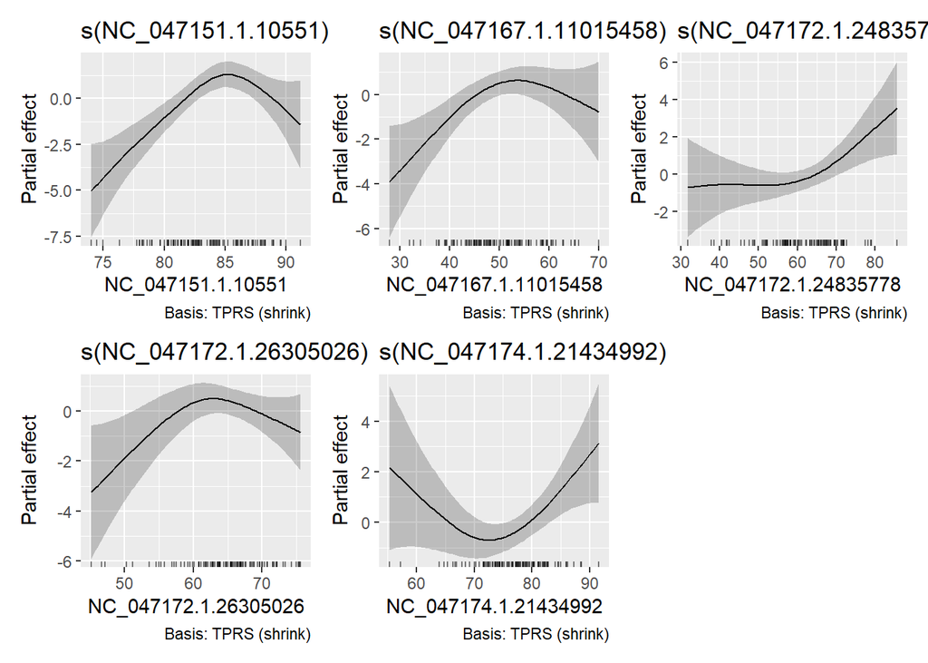

```r
draw(gam_model3)
```

```r
# get estimates for the plot
smooth_estimates(gam_model3)
```

```
## # A tibble: 500 × 10
##    .smooth    .type .by   .estimate   .se NC_047151.1.10551 NC_047167.1.11015458
##    <chr>      <chr> <chr>     <dbl> <dbl>             <dbl>                <dbl>
##  1 s(NC_0471… TPRS… <NA>      -5.01 1.29               74.0                   NA
##  2 s(NC_0471… TPRS… <NA>      -4.89 1.24               74.2                   NA
##  3 s(NC_0471… TPRS… <NA>      -4.76 1.18               74.4                   NA
##  4 s(NC_0471… TPRS… <NA>      -4.63 1.13               74.6                   NA
##  5 s(NC_0471… TPRS… <NA>      -4.51 1.08               74.7                   NA
##  6 s(NC_0471… TPRS… <NA>      -4.38 1.04               74.9                   NA
##  7 s(NC_0471… TPRS… <NA>      -4.26 0.995              75.1                   NA
##  8 s(NC_0471… TPRS… <NA>      -4.13 0.954              75.3                   NA
##  9 s(NC_0471… TPRS… <NA>      -4.01 0.917              75.4                   NA
## 10 s(NC_0471… TPRS… <NA>      -3.88 0.882              75.6                   NA
## # ℹ 490 more rows
## # ℹ 3 more variables: NC_047172.1.24835778 <dbl>, NC_047172.1.26305026 <dbl>,
## #   NC_047174.1.21434992 <dbl>
```

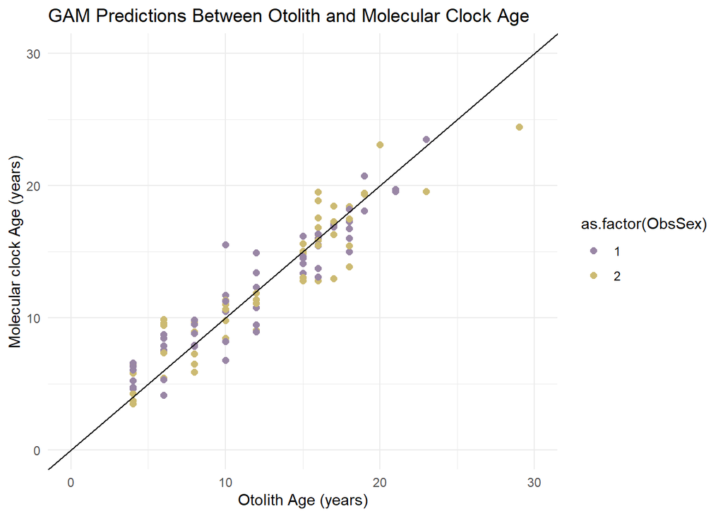

```r
## plot data
ggplot(aes(x = Age, y = fit,color = as.factor(ObsSex)), data = df_preds) +
  geom_point(size = 2)+
  ylim(0, 30) + xlim(0, 30) +
  geom_abline(slope = 1,intercept = 0)+
  xlab("Otolith Age (years)") +
  ylab("Molecular clock Age (years)") +
  ggtitle("GAM Predictions Between Otolith and Molecular Clock Age") +
  scale_color_manual(values = c(wes_palette("IsleofDogs1")[1],wes_palette("IsleofDogs1")[3]))+
  theme_classic(base_size = 18) +
  theme_minimal()
```

```r
# save predictions for figures
preds_comb <- full_join(res_comb_all,gam_res)
```

[output not shown]

```r
write.csv(preds_comb,file = "PredsOnly_BestModels.csv",quote = F,row.names = F,append = F)
```